# README

[figure not shown]

# mousePrep Package

`mousePrep` provides a lightweight set of preprocessing utilities for **mouse movement datasets**. It helps turn raw, mouse logs (often containing inconsistent column names, mixed event types and device, timing issues etc) into **clean, standardized, analysis-ready** trajectory tables.

The package focuses on the practical steps that typically come before modelingmachine learning: standardizing raw inputs, filtering and scoping to valid observations, handling device and event-related observations (e.g., touch devices, resize events), calculating and aligning time variables, resolving repeated visits, and preparing outputs that can be exported in desired formats.

## Workflow overview

A typical workflow is:

1. **Standardize raw inputs** so the upcoming functions can be applied consistently.
2. **Clean** remove invalid trajectories.
3. **Feature transformations** derive screen geometry and key time variables (e.g., initiation time, response time, move time).
4. **Handle outliers** such as flagging and removingslow-move outliers, and repeated visits per screen.
5. **Export a cleaned dataset** export the clean and standardized output for further processing.

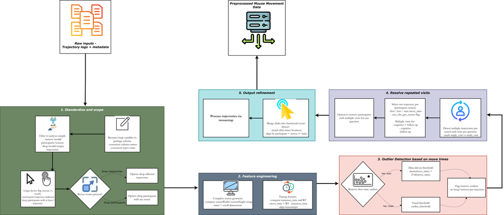

mousePrep preprocessing workflow

## Standardization first

For consistent use of the functions, it is recommended that the raw datasets are standardized using `standardize_cols()`. This step maps column names and formats into a common schema, which will reduce the need to specify parameter names in later functions.

## Precursor to `mousetrap`

`mousePrep` can be used in conjunction with the **`mousetrap`** package. Together, the two packages support data cleaning and preparation for subsequent analyses such as feature engineering and statistical modeling: `mousePrep` focuses broadly on standardizing and filtering raw logs, while `mousetrap` can be used for trajectory processing and analysis workflows after preprocessing.

## Reference

A list of all package functions is available **[here](https://soda-lmu.github.io/mousePrep/reference.html)**.

## Installation guide

To install the package from Github, you need the devtools package . The development version can be installed via `devtools::install_github("soda-lmu\mousePrep")`.